# Lab 2.2 - Transformación

En este laboratorio trabajaremos con datos procedentes de una encuesta sobre los hábitos de los fumadores en el Reino Unido. Los datos poceden del National STEM Centre, Large Datasets from stats4schools, https://www.stem.org.uk/resources/elibrary/resource/28452/large-datasets-stats4schools.

Los datos se encuentran en la carpeta data del repositorio. Puedes cargarlos utilizando

```r
library(tidyverse)
fumar <- read_csv("data/smoking.csv")
```

La variables recogidas son (entre paréntesis aparecen los niveles que toman):

- `gender`: Género
- `age`: Edad
- `marital_status`: Estado civil (Divorced, Married, Separated, Single and Widowed)
- `highest_qualification`: Nivel más alto de educación (A Levels, Degree, GCSE/CSE, GCSE/O Level, Higher/Sub Degree, No Qualification, ONC/BTEC y Other/Sub Degree)
- `nationality`: Nacionalidad (British, English, Irish, Scottish, Welsh, Other, Refused y Unknown)
- `ethnicity` : Etnia (Asian, Black, Chinese, Mixed, White y Refused Unknown)
- `gross_income`: Salario bruto (Under 2,600, 2,600 to 5,200, 5,200 to 10,400, 10,400 to 15,600, 15,600 to 20,800, 20,800 to 28,600, 28,600 to 36,400, Above 36,400, Refused y Unknown)
- `region`: Region (London, Midlands & East Anglia, Scotland, South East, South West, The North y Wales)
- `smoke` : Fumador (No y Yes)
- `amt_weekends`: Número de cigarros diarios en fin de semana
- `amt_weekdays`: Número de cigarros diarios entre semana
- `type`: Tipo de cigarrilos (Packets, Hand-Rolled, Both/Mainly Packets y Both/Mainly Hand-Rolled)

## Ejercicio 1

¿Cuántas observaciones hay en el dataset para cada género? ¿Qué proporción de mujeres son fumadoras? ¿Y de hombres?

## Ejercicio 2

Selecciona la variable `amt_weekends`, ordenala de forma decreciente y muestra los primeros 10 valores. Haz lo mismo con `amt_weekdays`, ¿qué observas?

## Ejercicio 3

¿Qué valores únicos presenta la variable `gross_income`?

Sustituye los valores Unknown con `NA` y vuelve a calcular los valores únicos de la variable.

## Ejercicio 4

Muestra las 10 últimas filas del dataset

## Ejercicio 5

¿Cuál es la media de cigarrillos diarios entre semana que fuman los menores de 30? ¿Y los fines de semana? **Nota**: Si observas `NA` determina el posible origen de esos valores ausentes y su tratamiento,

## Ejercicio 6

Calcula media, mediana, y desviación estándar de cigarrillos/dia en fin de semana y entre semana por grupos de edad menor o igual a 20, 20-30, …, >90. Resume las conclusiones de los resultados observados.

*Nota*: Crea una nueva variable llamada `decada` utilizando la función `case_when`. Los niveles de esta variable han de ser `"<=20","20-30","30-40", "40-50", "50-60", "60-70", "70-80", "80-90", ">90"`.

## Ejercicio 7

Ordena las distintas etnias en orden decreciente de proporción de fumadores en la muestra. Excluye aquellas observaciones con etnia desconocida o no declarada.

## Ejercicio 8

Reproduce el siguiente gráfico. Extrae alguna conclusión.

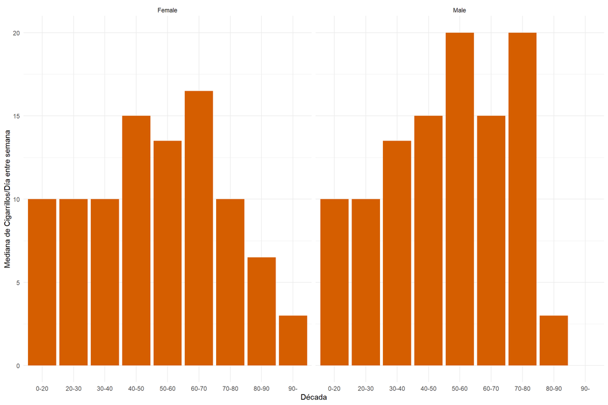

## Ejercicio 9

¿Qué tipos de tabaco son más populares en las distintas franjas de salario bruto? ¿Y en las distintas franjas de edad?

*Nota*: utiliza la variable decada creada anteriormente

## Ejercicio 10

¿Cuál es la diferencia entre estos dos códigos?

```r
fumar %>% count(gender, smoke) %>% mutate(prop=n/sum(n))
```

```r
fumar %>% group_by(gender, smoke) %>% summarise(n=n()) %>%
  mutate(prop=n/sum(n))
```

## Ejercicio 11

¿Entre la gente que no está casada, cuántos cigarros/día entre semana se fuman de media por nivel de estudios?

## Ejercicio 12

En numerosas ocasiones, ante la presencia de valores ausentes, es útil substituírlos por un valor. A este proceso se le conoce como imputación. Una de las técnicas más comunes de imputación de variables categóricas, consiste en substituír los valores ausentes por el valor más probable en cierto segmento de la población (la moda).

Por ejemplo, podemos sustituír los valores desconocidos o no declarados de la variable `ethnicity` por la etnia más frecuente en los datos, y asumir que el porcentaje de error será pequeño. Una estrategia quizás más inteligente es sustituír los valores desconocidos o no declarados de la variable `ethnicity` por la etnia más prevalente en la nación correspondiente. En este ejercicio, has de realizar esto último. Para ello, ayudate de la siguiente función para el cálculo de la moda.

```r
calc_mode <- function(x){

  x <- x[!x %in% c("Refused", "Unkown")]
  distinct_values <- unique(x)
  distinct_tabulate <- tabulate(match(x, distinct_values))
  distinct_values[which.max(distinct_tabulate)]

}
```

*Nota*: Excluye las observaciones con nacionalidad no conocida o no declarada. ¿Qué sucede si las incluyes?